# Home Assignment - Nonparametric Statistics - 2023

Thi Lan Anh Nguyen

# Task 1

1. Generate a sample with n=1000 from a Gamma distribution with shape=2 and rate=3. Use seed=656. Plot a histogram of your data.

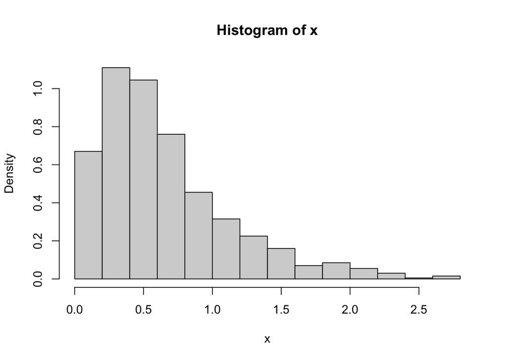

```r
set.seed = 656
x = rgamma(n = 1000, shape = 2, rate = 3)

hist(x, probability = T)
```

2. Write a function that would use the R-function hist() to estimate a pdf of X in an arbitrary point $x_0$ (scalar). The new function should have the data, the evaluation point and the number of breaks as arguments (suppress the plot).

```r
my.hist = function(x,x0,nb){
  # x: sample
  # x0: point(s) of interest
  # nb: number of breaks

  #we can either create a vector giving breakpoints or just a single number giving number of bins
  #hist = hist(x, breaks = seq(min(x),max(x)),length.out = nb), plot = F)
  hist = hist(x, breaks = nb-1, plot = F)
  for (i in 1:length(hist$breaks)){
    if ((x0 >= hist$breaks[i])&(x0 < hist$breaks[i+1])){
        f = hist$dens[i]
    }
  }
  return(f)
}
#my.hist(x, 2/3, 6)
```

3. Using the R-function hist(), perform a Monte-Carlo (MC = 1000) bias/variance analysis of the histogram estimator in point $x_0 = E(X)$ depending on the number of breaks. Use your custom function from b). Use samples of size n=1000 from the distribution in a).

```r
mc = 1000
b.mc = 3:500
x0 = 2/3

# Bins loop
n = 1000
dens.mc = matrix(0,nrow=mc, ncol=length(b.mc))

for(i in 1:length(b.mc)){
  for(imc in 1:mc){
    x = rgamma(n,shape = 2, rate = 3)
    dens.mc[imc,i] = my.hist(x,x0,b.mc[i])
  }
}
bias.b = -colMeans(dens.mc) + dgamma(x0,2,3)
var.b = apply(dens.mc,2,var)
```

4. Plot the paths as such:

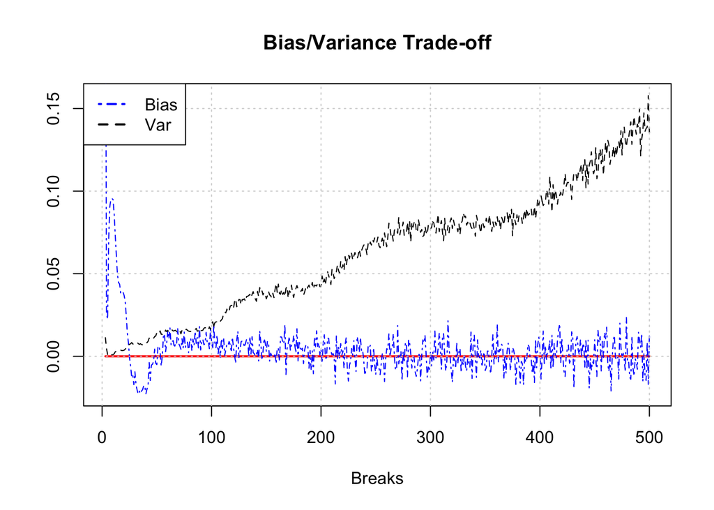

```r
plot(b.mc, rep(0, times=length(b.mc)), type="l",
     col="red",lwd=2,ylim=c(min(bias.b),max(var.b)),
     xlab="Breaks",ylab="",
     main="Bias/Variance Trade-off")
lines(b.mc,bias.b,col="blue",lwd=1,lty=4)
lines(b.mc,var.b,lwd=1,lty=2)
grid()
legend("topleft",c("Bias","Var"),col=c("blue","black"),lty=c(4,2),lwd=2)
```

# Task 2

1. Perform the same bias/variance analysis as in task 1. using the same data set for a KDE with the R function density(). You should base your simulation on the bandwidth. Use a Gaussian kernel.

```r
#In order to compare, we calculate the bandwidth based on number of breaks from task 1

mc = 1000
bw.mc = (max(x) - min(x))/(b.mc-1)
x0 = 2/3

# Bins loop
n = 1000
dens.mc = matrix(0, nrow=mc, ncol=length(bw.mc))

for(i in 1:length(bw.mc)){
  for(imc in 1:mc){
    x = rgamma(n, shape = 2, rate = 3)
    dens.mc[imc,i] = approxfun(density(x, bw = bw.mc[i], kernel = "gaussian" ))(x0)
  }
}

bias.b = -colMeans(dens.mc) + dgamma(x0,2,3)
var.b = apply(dens.mc,2,var)
```

2. Plot your results.

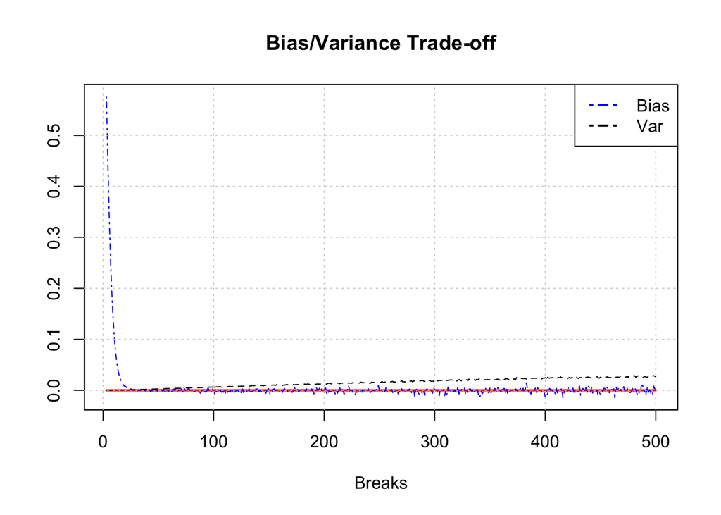

```r
#In order to compare, we keep the x-axis as number of breaks

plot(b.mc, rep(0, times=length(b.mc)), type="l",
     col="red",lwd=2,ylim=c(min(bias.b), max(bias.b)),
     xlab="Breaks",ylab="",
     main="Bias/Variance Trade-off")
lines(b.mc,bias.b,col="blue",lwd=1,lty=4)
lines(b.mc,var.b,lwd=1,lty=2)
grid()
legend("topright",c("Bias","Var"),col=c("blue","black"), lty=c(4,4),lwd=2)
```

```r
# Comment: we can see that KDE performs better in comparison to histogram in this case with quick convergence to 0 of bias and much smaller variance
```

# Task 3

1. Draw a random sample $X$ from $\chi^2(4)$ with $n=500$. Using this sample generate the data according to the true model
   $$Y = -0.5 -
   1.2 \cos(\sqrt{X}) + \varepsilon, \qquad \qquad \varepsilon
   \stackrel{iid}{\sim}\mathcal{N}(0,1)$$
   : Use $seed=656$ for $X$ and $seed=757$ for $\varepsilon$.

```r
n = 500

set.seed(656)
x = rchisq(n,4)

set.seed(757)
eps = rnorm(n, 0, 1)

y = -0.5 - 1.2*cos(sqrt(x)) + eps
```

2. Plot the data cloud and the true model in one graph as such:

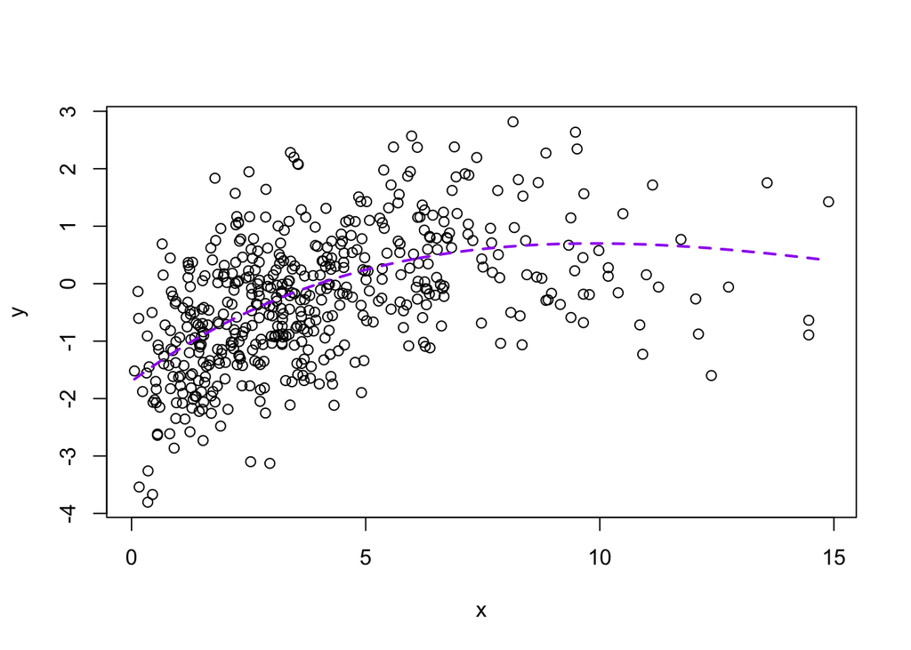

```r
plot(x,y)
order = order(x)
lines(x[order], y = -0.5 - 1.2*cos(sqrt(x[order])), col = "purple", lwd = 2, lty = 2)
```

3. Use functions from package KernSmooth to estimate a local linear regression for the given data (x,y). Use the optimal bandwidth. Plot your result in the graph from b).

```r
h.opt = 1.059*sd(x)*(n^(-1/5))
library(KernSmooth)
```

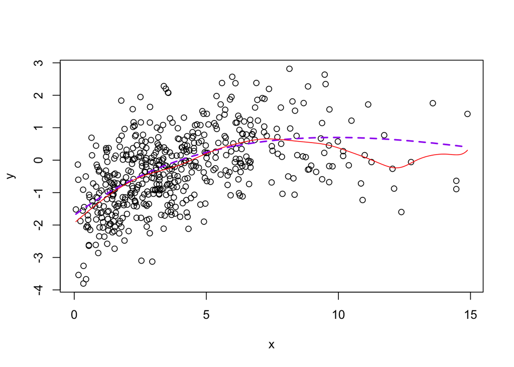

```r
fit = locpoly(x, y, bandwidth = h.opt)

plot(x,y)
order = order(x)
lines(x[order], y = -0.5 - 1.2*cos(sqrt(x[order])), col = "purple", lwd = 2, lty = 2)
lines(fit, col = "red")
```